# Prosper Loans Exploration

# Bivariate Analysis

### Did you observe any interesting relationships between the other features (not the main feature(s) of interest)?

Lender Yield had a very strong correlation to borrower rate with Lender Yield increasing linearly with increase in borrower rate. Also intersting was debt-to-income ratio and its relationship to income range. Other varaibles were correlated as well. For example, Individuals with a high income recieve larger loans with lower rates.

### What was the strongest relationship you found?

The strongest relationship is between BorrowerRate and LenderYield, it was almost 1 to 1.

# Multivariate Plots Section

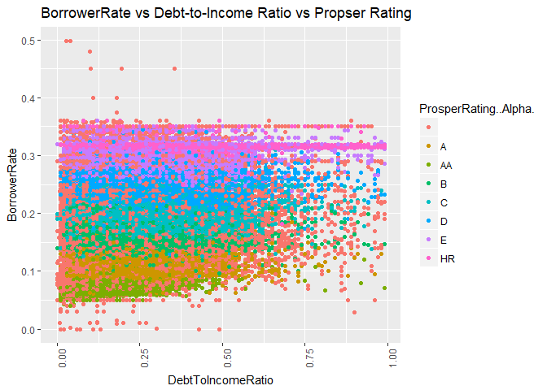

This chart was included in the bivariate section, however it has been colored here using the Prosper Rating and included as a multivariate plot. The chart shows consistency of rates within the prosper ratings

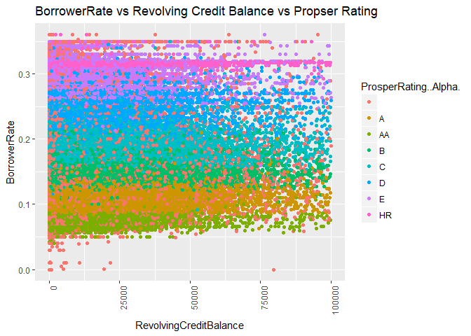

This chart was included in the bivariate section, however it has been colored here using the Prosper Rating and included as a multivariate plot. The chart shows consistency of rates within the prosper ratings

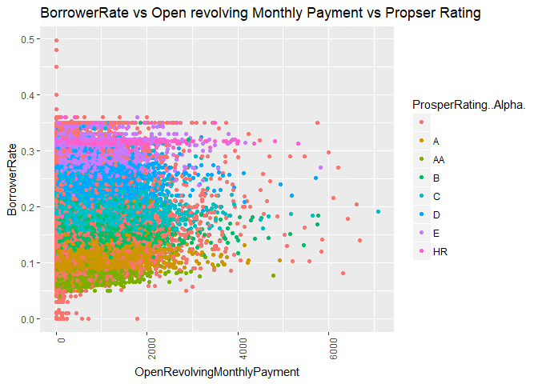

This chart was included in the bivariate section, however it has been colored here using the Prosper Rating and included as a multivariate plot. The chart shows consistency of rates within the prosper ratings

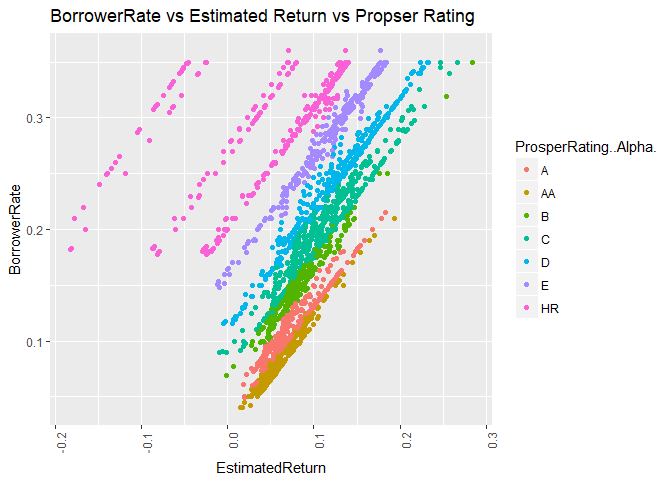

This chart was included in the bivariate section, however it has been colored here using the Prosper Rating and included as a multivariate plot. The chart shows consistency of rates within the prosper ratings

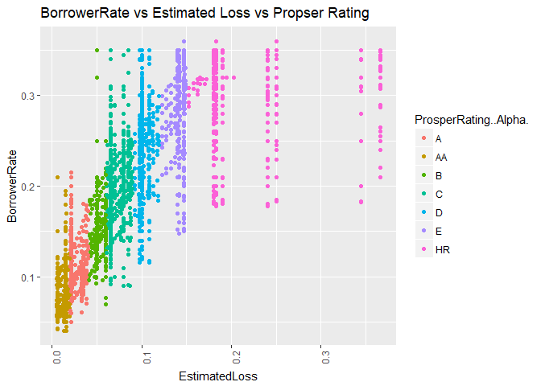

This chart was included in the bivariate section, however it has been colored here using the Prosper Rating and included as a multivariate plot. The chart shows consistency of rates within the prosper ratings

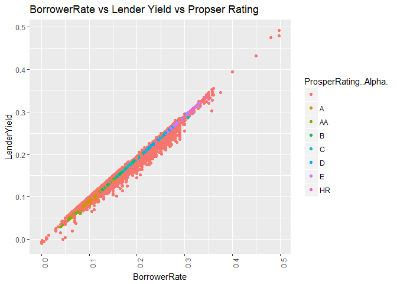

Borrower Rate and LenderYield are highly correlated. This chart was included in the bivariate section, however it has been colored here using the Prosper Rating and included as a multivariate plot. The chart shows consistency of Rates within the prosper ratings

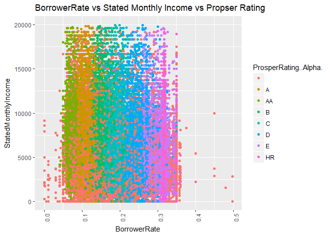

Rate and monthly income are weakly correlated but adding the credit rating indicates that rates are consistent across similar income levels

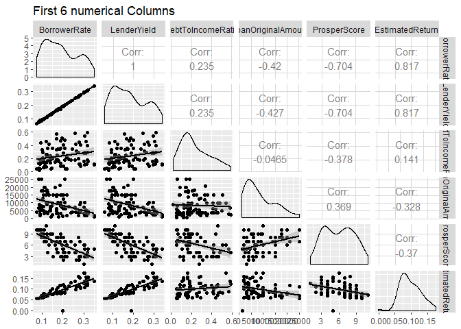

Correlation matrix to summarize and quantify some of the relationships noted earlier

# Multivariate Analysis

### Talk about some of the relationships you observed in this part of the investigation. Were there features that strengthened each other in terms of looking at your feature(s) of interest?

This analysis helps us better understand the risk and estimated losses for investing in a borrowesr with certain ratings and other factors. We investigated the relationship between debt, income and monthly loan payments for our borrowers.

### Were there any interesting or surprising interactions between features?

Most Investors prefer to invest in low risk, low borrower rate loans despite the high lender yield for loans taken on higher borrower rate. Revolving Debt and revolving debt payments seemed to correlated in the opposite direction.

### OPTIONAL: Did you create any models with your dataset? Discuss the strengths and limitations of your model.

No. I did not attempt to create a model.

# Final Plots and Summary

### Plot One

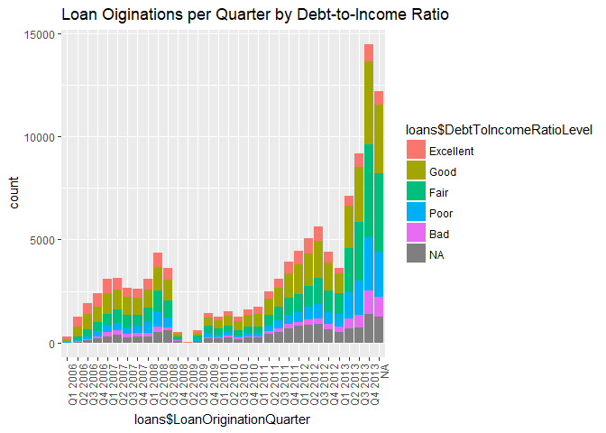

### Plot Two

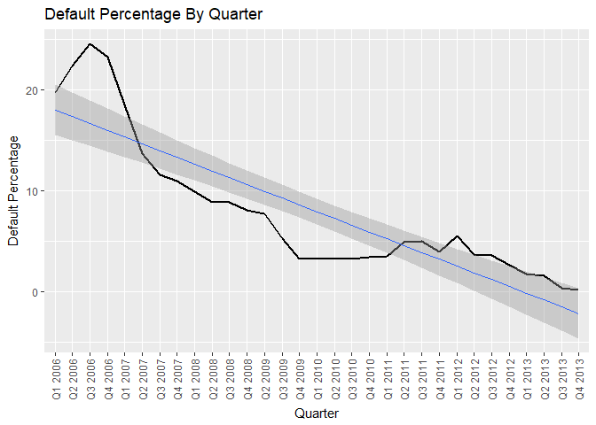

### Plot Three

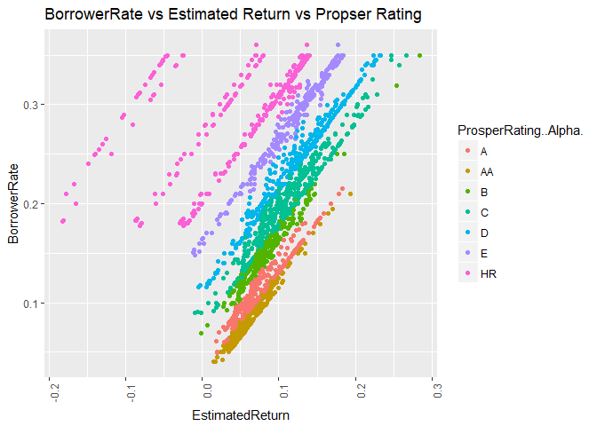

### Description Three

I’ve chosen this plot because shows strong relationship between borrower rate and the estimated return.

# Reflection

Prior to beginning work on the project I assumed that there would be data related to requests that did not become loans. I was interested to know about requests that were not funded and why. However, after looking into the data it appeared to contain only data for funded loans so I had to modify my approach. My initial challenges with the data were related to the importation itself. It appears that R imports dates and other strings a factors by default and that it’s not very good at doing so. This dataset revealed to me the importance of having a level of domain knowledge with respect to the data. I spent a lot of time trying to familiarize myself with the lending domain and its terminology and many of the terms meant almost nothing to me and this made it hard for me to know where to look for possible relationships because I had no “intuition” regarding the data. The primary takeaway for me was that these types of industries need to constantly work toward improved risk identification and mitigation policies in order to reduce defaults and increase investor yields. As noted above, the relatiohships between revolving credit amounts and monthly payment and borrower rate are counter to my expectation, future work might investigate this further.

# References

PDF: [R Markdown Cheatsheet](http://bit.ly/1SuNTo9)

SITE: [Computing by groups within data.frames with dplyr and broom:](http://bit.ly/2oOhWQr)  
SITE: [Cookbook for R](http://bit.ly/1iyqHp7)  
SITE: [Seven Easy Graphs to Visualize Correlation Matrices in R](http://bit.ly/2I0bcrJ)  
SITE: [Binning Outliers in a Histogram](http://bit.ly/2H4gOQh)

BOOK: R for Data Science, by Hadley Wicham & Garrett Grolemund  
BOOK: R in Action: Data Analysis and Graphics in R, by Robert I. Kabacoff